# Introduction to conditioned Latin hypercube sampling with the clhs package

Pierre Roudier

2025-10-20

# A simple example

```r
data(diamonds, package = 'ggplot2')
diamonds <- data.frame(diamonds)
head(diamonds)
```

```
##   carat       cut color clarity depth table price    x    y    z
## 1  0.23     Ideal     E     SI2  61.5    55   326 3.95 3.98 2.43
## 2  0.21   Premium     E     SI1  59.8    61   326 3.89 3.84 2.31
## 3  0.23      Good     E     VS1  56.9    65   327 4.05 4.07 2.31
## 4  0.29   Premium     I     VS2  62.4    58   334 4.20 4.23 2.63
## 5  0.31      Good     J     SI2  63.3    58   335 4.34 4.35 2.75
## 6  0.24 Very Good     J    VVS2  62.8    57   336 3.94 3.96 2.48
```

```r
nrow(diamonds)
```

```
## [1] 53940
```

```r
library(clhs)
res <- clhs(diamonds, size = 100, use.cpp = TRUE)
str(res)
```

```
##  num [1:100] 15434 51042 213 32976 21474 ...
```

# Tweaking the parameters

(work in progress)

# Including existing samples in the sampling routine

This functionality is controlled by the `include` option, which can be used to specify the row indices of samples that needs to be included in the final sampled set.

```r
suppressWarnings(RNGversion("3.5.0"))
set.seed(1)

candidates_samples <- data.frame(
  x = runif(500),
  y = rnorm(500, mean = 0.5, sd = 0.5)
)

existing_samples <- data.frame(
  x = runif(5),
  y = runif(5)
)

res <- clhs(
  x = rbind(existing_samples, candidates_samples),
  size = 10,
  include = 1:5
)
```

In this case we have 5 individuals (red triangles) that need to be retained in the selected set of samples:

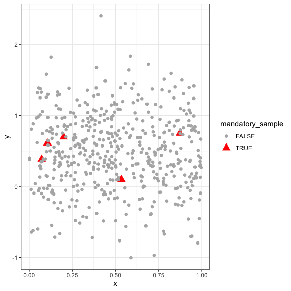

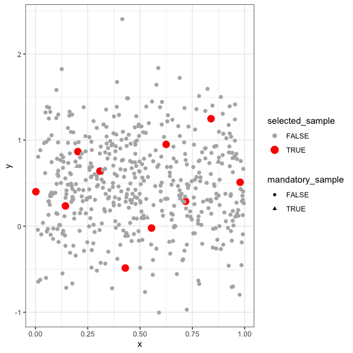

# Cost-constrained implementation

(work in progress)

```r
diamonds$cost <- runif(nrow(diamonds))
res_cost <- clhs(diamonds, size = 100, progress = FALSE, iter = 1000, cost = 'cost')
```

# DLHS

(work in progress)

# Plotting the results

If you want to report on the cLHS results, e.g. plot the evolution of the objective function, or compare the distribution of attributes in the initial object and in the sampled subset, you need to switch the `simple` option to `FALSE`. Instead f simply returning a numeric vector giving the index of the sampled individuals in the original object, a specific, more complex will be returned. This object can be handled by a specific `plot` method:

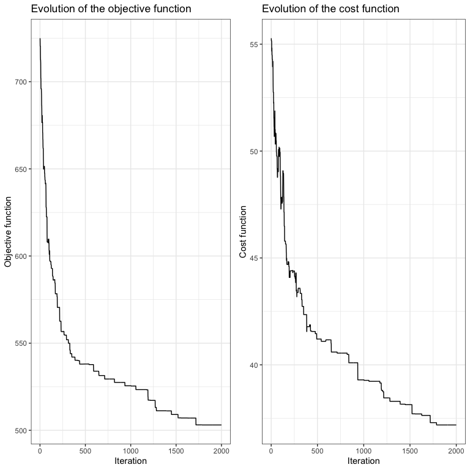

```r
res <- clhs(diamonds, size = 100,cost = "cost", simple = FALSE, progress = FALSE, iter = 2000)
plot(res,c("obj","cost"))
```

The default plotting method plots the evolution of the objective function with the number of iterations. However, you can get more details using the `modes` option, which controls which indicators are plotted. Three `modes` can be simultaneously plotted:

- `obj`: evolution of the objective function (default)
- `cost`: evolution of the cost function (if present)
- `dens` OR `box` OR `hist`: comparison of the distributions of each attribute in the original object and in the proposed sample, respectively using probability density functions, boxplots or histograms. Note that categorical attributes are always reported using dotplots.

These modes should be given as a vector of characters.

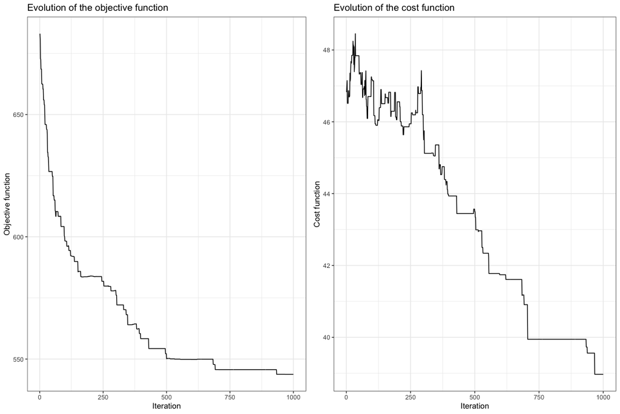

```r
res_cost <- clhs(diamonds, size = 100, progress = FALSE, iter = 1000, cost = 'cost', simple = FALSE, use.cpp = F)
plot(res_cost, c('obj', 'cost'))
```

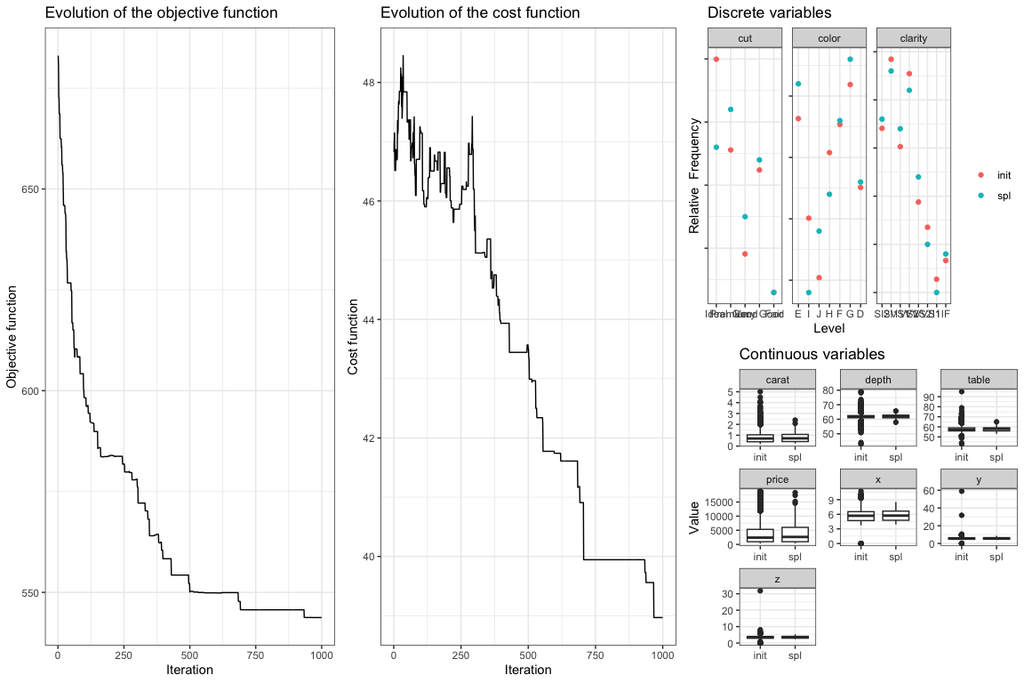

```r
plot(res_cost, c('obj', 'cost', 'box'))
```